# Space Launches

```python
import pandas as pd
import numpy as np
import matplotlib.pyplot as plt
from plotnine import ggplot, aes, geom_point
import seaborn as sns
import math
import datetime as dt
import statsmodels.formula.api as smf
from sklearn import preprocessing, svm
from sklearn.model_selection import train_test_split
from sklearn.linear_model import LinearRegression
from sklearn.metrics import mean_absolute_error, mean_squared_error
from sklearn.datasets import load_linnerud
from sklearn.svm import LinearSVR
from sklearn.pipeline import make_pipeline
from sklearn.preprocessing import StandardScaler
from sklearn.datasets import make_regression
from scipy import stats
from sklearn.svm import SVR
from sklearn.model_selection import GridSearchCV
from sklearn.metrics import classification_report
from sklearn.metrics import r2_score
from sklearn.model_selection import cross_val_score
```

The data I selected records every space launch from 1957 to 2020. It includes the name of the company responsible for the launch, the cost of the rocket launched, the location of the launch and the company's country of origin, whether the mission was private or state run, the status of the mission, and a few other descriptive variables. Using this data, I plan on finding different factors that contributed to the success (or failure) of these launches. Success can be measured in different ways. The status of the mission is an obvious metric to use to measure success, and the current status of the rocket and a company's ratio of successful to overall launches are some of several other benchmarks we can use determine success. I look forward to analyzing such relationships between the variables provided in the dataset.

```python
launches = pd.read_csv('Global_Space_Launches.csv')
launches.head()
```

|  | Company Name | Location | Detail | Status Rocket | Rocket | Status Mission | Country of Launch | Companys Country of Origin | Private or State Run | DateTime | Year | Month | Day | Date | Time |
| --- | --- | --- | --- | --- | --- | --- | --- | --- | --- | --- | --- | --- | --- | --- | --- |
| 0 | SpaceX | LC-39A, Kennedy Space Center, Florida, USA | Falcon 9 Block 5 \| Starlink V1 L9 & BlackSky | StatusActive | 50.0 | Success | USA | USA | P | 2020-08-07 05:12:00+00:00 | 2020 | 8 | 7 | 07/08/2020 | 05:12 |
| 1 | CASIC | Site 9401 (SLS-2), Jiuquan Satellite Launch Ce... | Long March 2D \| Gaofen-9 04 & Q-SAT | StatusActive | 29.75 | Success | China | China | S | 2020-08-06 04:01:00+00:00 | 2020 | 8 | 6 | 06/08/2020 | 04:01 |
| 2 | SpaceX | Pad A, Boca Chica, Texas, USA | Starship Prototype \| 150 Meter Hop | StatusActive | NaN | Success | USA | USA | P | 2020-08-04 23:57:00+00:00 | 2020 | 8 | 4 | 04/08/2020 | 23:57 |
| 3 | Roscosmos | Site 200/39, Baikonur Cosmodrome, Kazakhstan | Proton-M/Briz-M \| Ekspress-80 & Ekspress-103 | StatusActive | 65.0 | Success | Kazakhstan | Russia | S | 2020-07-30 21:25:00+00:00 | 2020 | 7 | 30 | 30/07/2020 | 21:25 |
| 4 | ULA | SLC-41, Cape Canaveral AFS, Florida, USA | Atlas V 541 \| Perseverance | StatusActive | 145.0 | Success | USA | USA | P | 2020-07-30 11:50:00+00:00 | 2020 | 7 | 30 | 30/07/2020 | 11:50 |

## Finding the Number of Times Each Country has Succeeded/Failed in its Launches

I started off by plotting the number of times each country had succeeded and failed in terms of mission status, over the 1957-2020 time period. When I was inspecting the 'Status Mission' column of the dataframe, I realized that the number of total Prelaunch Failures and Partial Failures was a small fraction of the number of Successes and Failures. In addition, I chose to make an assumption that we can consider Prelaunch Failures and Partial Failures as just Failures in some sense. Partial Failure or Prelaunch Failure indicate that the mission did not go exactly as planned, and this can be considered as a failure; so I decided to count them as Failure.

```
['Success' 'Failure' 'Prelaunch Failure' 'Partial Failure']
# of Successes:  3879
# of Failures:  339
# of Prelaunch Failures:  4
# of Partial Failures:  102
```

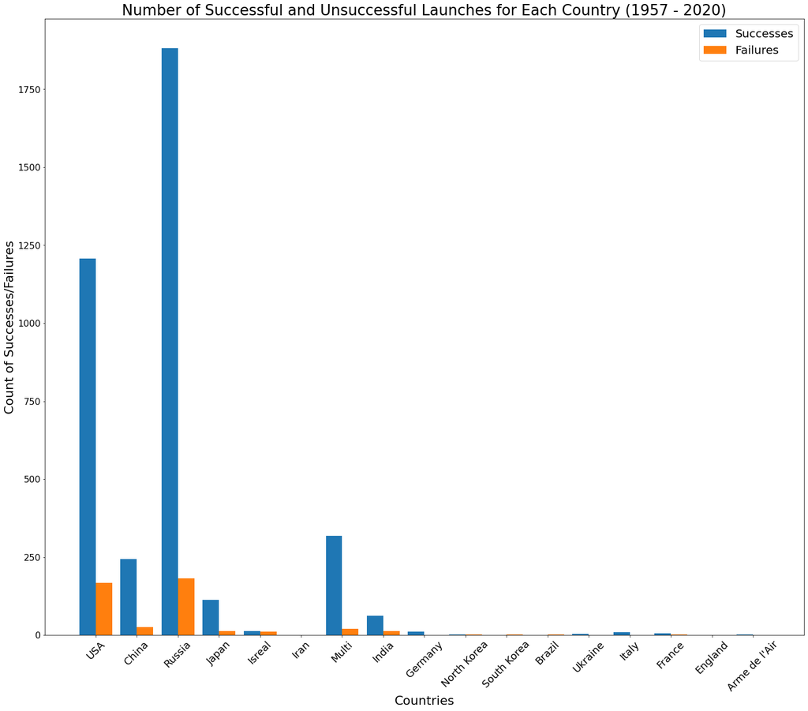

```python
# Plotting the number of times each unique country has succeeded and failed in launches

# We are given that there are 4 categorical variables that respresent 'Status Mission': Success, Failure, Prelaunch Failure, and Partial Failure
print(launches['Status Mission'].unique())

print('# of Successes: ', len(launches[launches['Status Mission'] == 'Success']))
print('# of Failures: ', len(launches[launches['Status Mission'] == 'Failure']))
print('# of Prelaunch Failures: ', len(launches[launches['Status Mission'] == 'Prelaunch Failure']))
print('# of Partial Failures: ', len(launches[launches['Status Mission'] == 'Partial Failure']))

# We can see that there are only four Prelaunch Failures and 102 Partial Failures throughout the entore dataset
# For the sake of this plot, I am going to consider Prelaunch Failures and Partial Failures as pure Failures

countries = launches['Companys Country of Origin'].unique().tolist()
failure_values = launches['Status Mission'].unique().tolist()
failure_values.remove('Success')

successes = []
failures = []

for country in countries:
    comp_df = launches[launches['Companys Country of Origin'] == country]
    success_count = len(comp_df[comp_df['Status Mission'] == 'Success'])
    failure_count = len(comp_df[comp_df['Status Mission'].isin(failure_values)])

    # Makes sure that every launch recorded for a country is classified as either a success or a failure (no missing values)
    if success_count + failure_count != len(comp_df):
        print('Missing values')

    successes.append(success_count)
    failures.append(failure_count)


X_axis = np.arange(len(countries))
f, ax = plt.subplots(figsize=(24,20))
plt.bar(X_axis - 0.2, successes, 0.4, label = 'Successes')
plt.bar(X_axis + 0.2, failures, 0.4, label = 'Failures')
plt.xticks(X_axis, countries, fontsize=18)
plt.xticks(rotation=45)
plt.yticks(fontsize=16)
plt.xlabel("Countries", fontsize=22)
plt.ylabel("Count of Successes/Failures", fontsize=22)
plt.title("Number of Successful and Unsuccessful Launches for Each Country (1957 - 2020)", fontsize=26)
plt.legend()
plt.legend(fontsize=20)
plt.show()
```

Here we can see that there is a significant disparity between the number of launches some countries have conducteed versus others. It would make sense to somehow normalize this data so that we can more easily compare the success rates of different countries

## Normalizing Success Rate for Countries (based on number of total launches attempted)

```python
# Normalize by finding ratio of success/failures over total launches for each country

success_ratio = []

for i in range(0,len(successes)):
    success_ratio.append(successes[i]/(successes[i] + failures[i]))
```

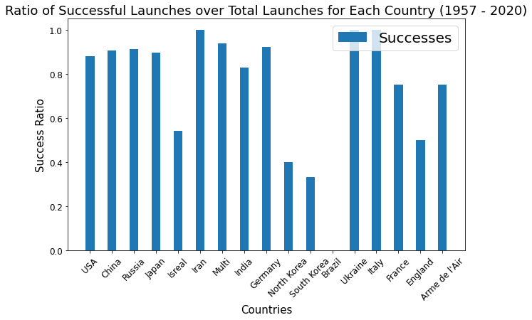

```python
# Now we can plot the normalized ratios of successes to measure the success each country has had with its launches

X_axis = np.arange(len(countries))
f, ax = plt.subplots(figsize=(10,6))
plt.bar(X_axis, success_ratio, 0.4, label = 'Successes')
plt.xticks(X_axis, countries, fontsize=12)
plt.xticks(rotation=45)
plt.yticks(fontsize=12)
plt.xlabel("Countries", fontsize=15)
plt.ylabel("Success Ratio", fontsize=15)
plt.title("Ratio of Successful Launches over Total Launches for Each Country (1957 - 2020)", fontsize=18)
plt.legend()
plt.legend(fontsize=20)
plt.show()
```

While we can compare the success rates between different countries, it doesn't seem like a very solid metric to solely use against a correlation with success. Especially once you keep in mind that there is a large difference between the number of launches different countries have conducted. For example, it is not entirely reasonable to compare a success ratio in the 0.80s of a country that has had hundreds of launches with a success ratio in the 0.30s of a country with three launches. After having this realization at this step, I decided to explore more variables to find their relationship with success. I started with looking at the cost of the rocket used for each launch.

## Fixing the name of the originally ' Rocket' column and dropping rows in which it has NaN values

```python
# fix ' Rocket' name
# make cols floats

launches.rename(columns = {' Rocket':'Rocket Cost'}, inplace = True)


old_costs = launches['Rocket Cost']
new_costs = []

for i in range(len(old_costs)):

    # if nan (all nan have the type float for some reason)
    if isinstance(old_costs[i], float):
        new_costs.append(old_costs[i])
    else:
        curr_cost = old_costs[i].replace(',', '')
        new_costs.append(float(curr_cost))

launches['Rocket Cost'] = new_costs
```

## Finding the relationship between the cost of a rocket and the status of the mission it's used in

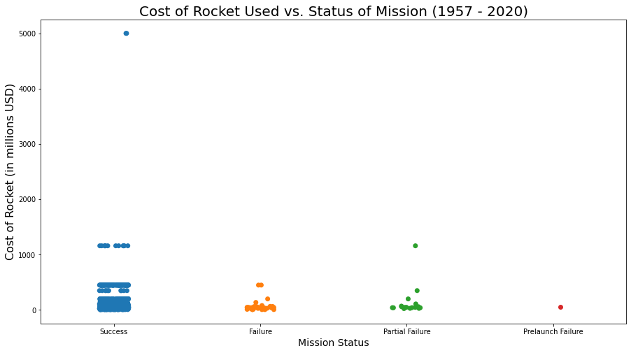

```python
rocket_cost_df = launches

mission_status = []
rocket_costs = []

# for the following step
activity_status = []

for index, row in rocket_cost_df.iterrows():
    if not math.isnan(row['Rocket Cost']):
        mission_status.append(row['Status Mission'])
        rocket_costs.append(row['Rocket Cost'])
        activity_status.append(row['Status Rocket'])

f, ax = plt.subplots(figsize=(15,8))
sns.stripplot(ax=ax, x=mission_status, y=rocket_costs, size=7)
ax.set_xlabel("Mission Status", size = 14)
ax.set_ylabel("Cost of Rocket (in millions USD)", size=16)
ax.set_title("Cost of Rocket Used vs. Status of Mission (1957 - 2020)", size=20)
```

From the plot above, we can see that the cost of the rocket used does not seem to be very strongly correlated with the status of the mission. It seems as though a rocket that costs anywhere between 0 and 1 billion dollars can fall under any of the four mission status categories. However, we can also see that as the rockets get much more expensive than $1 billion, they are very likely to fall under the category of success. In order to remove some extra variables that may be causing a lack of clarity in this relationship, I decide to include Partial Failure and Prelaunch Failure under the more general Failure category in the following step. My intention behind this was to hope to see a more clear contrast between solely success and failure.

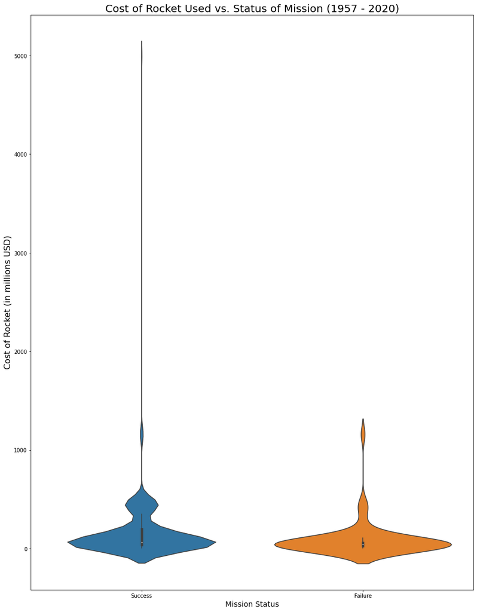

```python
# want to see distribution of rocket cost for both successes and failures (combine all types of failures into one)

for i in range(len(mission_status)):
    if 'Failure' in mission_status[i]:
        mission_status[i] = 'Failure'

f, ax = plt.subplots(figsize=(15,20))
sns.violinplot(x=mission_status, y=rocket_costs)
ax.set_xlabel("Mission Status", size = 14)
ax.set_ylabel("Cost of Rocket (in millions USD)", size=16)
ax.set_title("Cost of Rocket Used vs. Status of Mission (1957 - 2020)", size=20)
```

After plotting this violin plot, we see that although there isn't much of a visual different between the graphs for Success and Failures, there are a few distinct observations to note. First off, the graph for Success includes significant outliers which describe that rockets that are much more costly than average are related to successful missions. Also, we see a signifiant bulge in the Success graph at around $500 million, compared to the Failure graph at the same height. This means that successful missions used expensive rockets more frequently that unsuccessful ones. After drawing these conclusions, I decided to experiment some more with the cost-of-the-rocket variable.

## Finding the relationship between cost of rocket and mission status, versus whether that rocket is still currently active or not

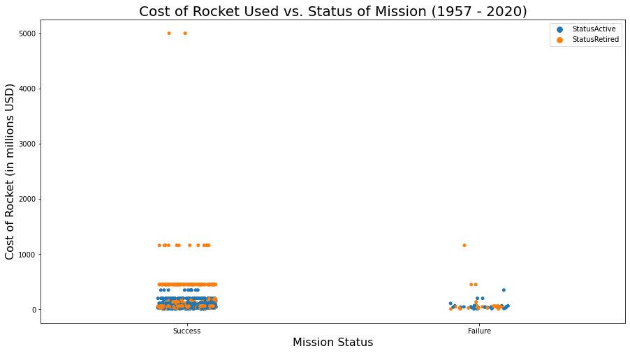

```python
# cost of rocket vs whether it is still active or not
f, ax = plt.subplots(figsize=(15,8))
sns.stripplot(ax=ax, x=mission_status, y=rocket_costs, hue=activity_status)
ax.set_xlabel("Mission Status", size = 16)
ax.set_ylabel("Cost of Rocket (in millions USD)", size=16)
ax.set_title("Cost of Rocket Used vs. Status of Mission (1957 - 2020)", size=20)
```

I was unable to make valid and relevant observations about the relationship between the cost of a rocket and whether it is still active or not using data visualization. So I decided I wanted to do more analysis on the Rocket Status variable to see if it is related to other columns in the dataset.

## Private vs. State Run missions and how they relate to the current status of the rockets used

```python
# public/private vs. statusActive
# make new df and add col to determine if launch is a success or a failure (just 2 categorical variables instead of 4)



status_binary = []

for index, row in launches.iterrows():
    if 'Failure' in row['Status Mission']:
        status_binary.append('Failure')
    else:
        status_binary.append(row['Status Mission'])

launches['S/F'] = status_binary

cross_tab_prop = pd.crosstab(index=launches['Private or State Run'],
                             columns=launches['S/F'],
                             normalize="index")
cross_tab_prop
```

| S/F Private or State Run | Failure | Success |
| --- | --- | --- |
| P | 0.084709 | 0.915291 |
| S | 0.111566 | 0.888434 |

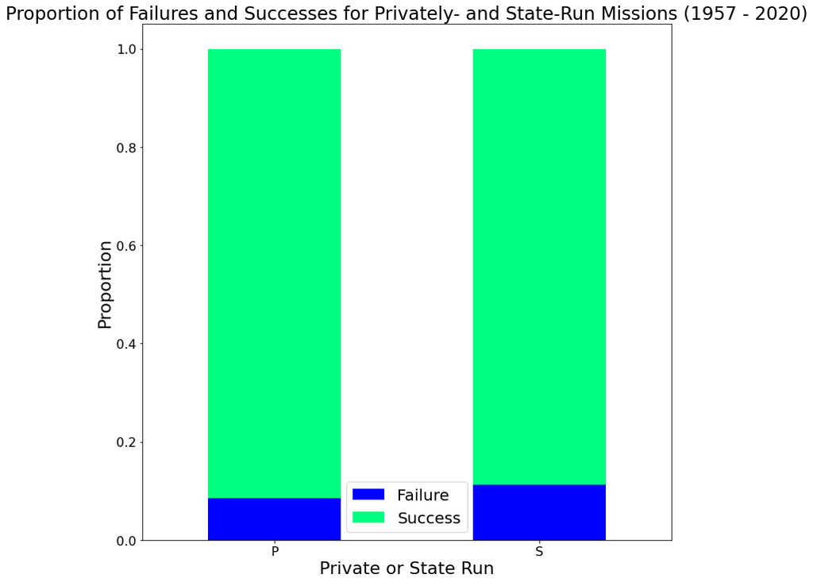

```python
cross_tab_prop.plot(kind='bar', stacked=True, colormap='winter', figsize=(12, 12))
plt.xticks(rotation=0)
plt.legend(loc="upper left", ncol=2)
plt.xlabel("Private or State Run", fontsize=22)
plt.ylabel("Proportion", fontsize=22)
plt.yticks(fontsize=16)
plt.xticks(fontsize=16)
plt.legend(fontsize=20)
plt.title("Proportion of Failures and Successes for Privately- and State-Run Missions (1957 - 2020)", fontsize=23)
```

From the bar plots above, we can determine that Success is more probable with privately run launches (although only slightly). This observation led me to further explore data related to the private industry. I started off with finding how privately run launches have been performing over time.

## Number of private missions conducted over time

```
Years  Private or State Run
1959   P                        1
1960   P                        5
1961   P                        8
1962   P                       14
1963   P                        9
                               ..
2016   P                       43
2017   P                       51
2018   P                       53
2019   P                       46
2020   P                       30
Length: 62, dtype: int64
```

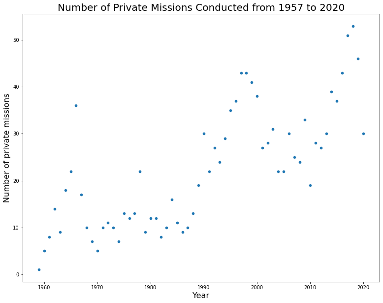

```python
launches['DateTime'] = pd.to_datetime(launches['DateTime'])
launches['Years'] = launches['DateTime'].dt.year

launches_new = launches
launches_new = launches_new[launches_new['Private or State Run'] == 'P']
yearly_privates = launches_new.groupby(['Years', 'Private or State Run']).size()
print(yearly_privates)

counts = list(yearly_privates)
years = set()

for index, row in launches.iterrows():
    if row['Private or State Run'] == 'P':
        years.add(row['Years'])

years = list(years)

f, ax = plt.subplots(figsize=(13,10))
sns.scatterplot(x=years, y=counts)
ax.set_xlabel("Year", size = 16)
ax.set_ylabel("Number of private missions", size=16)
ax.set_title("Number of Private Missions Conducted from 1957 to 2020", size=20)
```

Here, it seems like there is a linear relationship between the number of private missions being conducted and time. However, it is hard to assume this without testing it with a regression model. So I decided to assume a null hypothesis of having no relationship between year and number of private missions, and planned to model a regression which would accept or reject this null hypothesis.

## Hypothesis Testing and Linear Regression

```
Score:  0.8126593864069187
y-intercept:  -976.5708654026657
slope:  0.5020736284001117

    Actual  Predicted
0       33  32.095054
1       37  35.107496
2        1   6.991373
3       43  35.609569
4       18   9.501741
5       25  31.090907
6       13  15.024551
7       10  13.016256
8       16  19.543213
9       53  36.613717
10      19  22.053581
11      10  11.510035
12      30  30.588833
13      11  13.518330
14      27  23.559802
15      24  24.061876
Mean absolute error:  4.1819735121381
Mean squared error:  33.03927352539232
Root mean squared error:  5.747979951721502
```

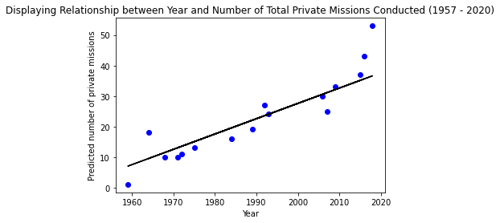

```python
years_new = np.array(years)
counts_new = np.array(counts)

X = years_new.reshape(-1,1)
y = counts_new.reshape(-1,1)

SEED = 42

X_train, X_test, y_train, y_test = train_test_split(X, y, test_size = 0.25, random_state = SEED)

regr = LinearRegression()
regr.fit(X_train, y_train)

print('Score: ', regr.score(X_test, y_test))
print('y-intercept: ', regr.intercept_.squeeze())
print('slope: ', regr.coef_.squeeze())
print()

# testing how strong the model is
y_pred = regr.predict(X_test)
# using X_test data to compare predicted y outputs with actual y outputs
df_preds = pd.DataFrame({'Actual': y_test.squeeze(), 'Predicted': y_pred.squeeze()})
print(df_preds)

# using metrics to evaluate the model
mae = mean_absolute_error(y_test, y_pred)
mse = mean_squared_error(y_test, y_pred)
rmse = np.sqrt(mse)
print('Mean absolute error: ', mae)
print('Mean squared error: ', mse)
print('Root mean squared error: ', rmse)
print()
# plot for visualizing regression line
plt.scatter(X_test, y_test, color ='b')
plt.plot(X_test, y_pred, color ='k')
plt.xlabel('Year')
plt.ylabel('Predicted number of private missions')
plt.title('Displaying Relationship between Year and Number of Total Private Missions Conducted (1957 - 2020)')
plt.show()
```

Next, I wanted to analyze something very similar, but slightly more robust: the ratio of private launches over all launches, yearly. This is very similar to the relationship that was tested above, but this time we are focused on the ratio of private launches yearly, rather than the frequency. This way, we are not only able to determine if the private-launches industry is growing over the years, but we'd also be able to find if we are seeing growth in that industry in terms of its ratio against the number of state-run launches yearly.

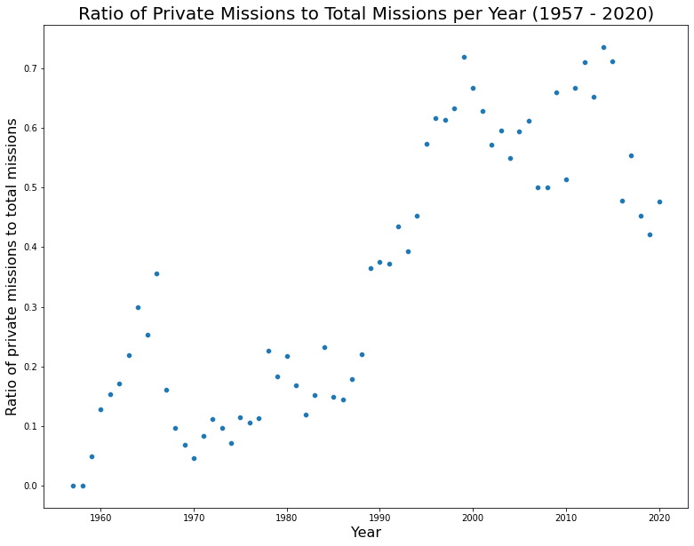

```python
# normalize above data: ratio of privates over all launches for that year

years_norm = list(launches['Years'])
years_norm.reverse()
years_norm = list(set(years_norm))
ratios = []

for year in years_norm:
    df = launches[launches['Years'] == year]
    total_count = 0
    private_count = 0

    for index, row in df.iterrows():
        if row['Private or State Run'] == 'P':
            private_count += 1
        total_count += 1

    ratios.append(private_count/total_count)

f, ax = plt.subplots(figsize=(13,10))
sns.scatterplot(x=years_norm, y=ratios)
ax.set_xlabel("Year", size = 16)
ax.set_ylabel("Ratio of private missions to total missions", size=16)
ax.set_title("Ratio of Private Missions to Total Missions per Year (1957 - 2020)", size=20)
```

The graph above also looks like it can be modeled using linear regression, so that was my next step. My null hypothesis was similar to last time's: there is no relationship between year and the ratio of private missions to total missions.

```
Score:  0.7475461972845613
y-intercept:  -19.949300748772007
slope:  0.01020759462375575

      Actual  Predicted
0   0.660000   0.557757
1   0.711538   0.619002
2   0.000000   0.026962
3   0.627907   0.476096
4   0.170732   0.078000
5   0.393443   0.394435
6   0.097087   0.190283
7   0.067961   0.149453
8   0.119403   0.282152
9   0.452991   0.649625
10  0.652174   0.598587
11  0.356436   0.118830
12  0.614286   0.435266
13  0.046729   0.159661
14  0.372881   0.374020
15  0.500000   0.537342
Mean absolute error:  0.10143570219527302
Mean squared error:  0.014837121909747356
Root mean squared error:  0.12180772516448764
```

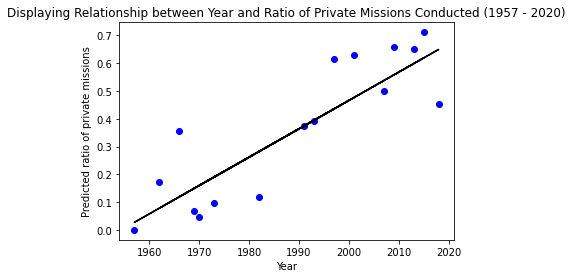

```python
years_new = np.array(years_norm)
ratios_new = np.array(ratios)

X = years_new.reshape(-1,1)
y = ratios_new.reshape(-1,1)

SEED = 42

X_train, X_test, y_train, y_test = train_test_split(X, y, test_size = 0.25, random_state = SEED)

regr = LinearRegression()
regr.fit(X_train, y_train)

print('Score: ', regr.score(X_test, y_test))
print('y-intercept: ', regr.intercept_.squeeze())
print('slope: ', regr.coef_.squeeze())
print()

# testing how strong the model is
y_pred = regr.predict(X_test)
# using X_test data to compare predicted y outputs with actual y outputs
df_preds = pd.DataFrame({'Actual': y_test.squeeze(), 'Predicted': y_pred.squeeze()})
print(df_preds)

# using metrics to evaluate the model
mae = mean_absolute_error(y_test, y_pred)
mse = mean_squared_error(y_test, y_pred)
rmse = np.sqrt(mse)
print('Mean absolute error: ', mae)
print('Mean squared error: ', mse)
print('Root mean squared error: ', rmse)
print()
# plot for visualizing regression line
plt.scatter(X_test, y_test, color ='b')
plt.plot(X_test, y_pred, color ='k')
plt.xlabel('Year')
plt.ylabel('Predicted ratio of private missions')
plt.title('Displaying Relationship between Year and Ratio of Private Missions Conducted (1957 - 2020)')
plt.show()
```

Additionally, while focused on the private missions, I was interested in the success they've had over the years, and what that would look like visually.

```
Privately run successes over the years:
Private or State Run  Years
P                     1960      1
                      1961      2
                      1962     10
                      1963      8
                      1964     14
                               ..
                      2016     42
                      2017     50
                      2018     50
                      2019     41
                      2020     28
Length: 61, dtype: int64
```

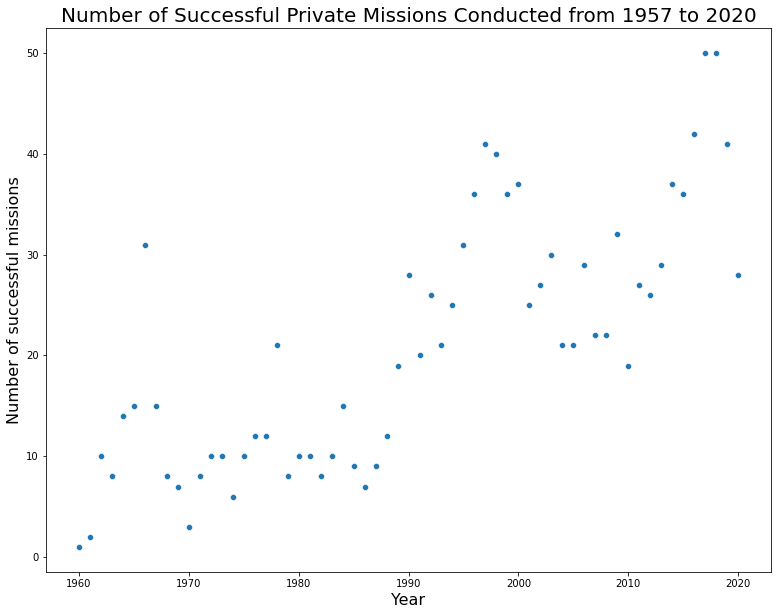

```python
launches_new = launches_new[launches_new['Status Mission'] == 'Success']
yearly_private_successes = launches_new.groupby(['Private or State Run', 'Years']).size()

print('Privately run successes over the years:')
print(yearly_private_successes)

counts = list(yearly_private_successes)
years = set()

for index, row in launches_new.iterrows():
    if row['Private or State Run'] == 'P':
        years.add(row['Years'])

years = list(years)

f, ax = plt.subplots(figsize=(13,10))
sns.scatterplot(x=years, y=counts)
ax.set_xlabel("Year", size = 16)
ax.set_ylabel("Number of successful missions", size=16)
ax.set_title("Number of Successful Private Missions Conducted from 1957 to 2020", size=20)
```

Once again, the relationship between the number of successful private missions and time seems like it can be a good fit for a linear regression model, with a null hypothesis: there is no relationship between the years and the number of successful private missions.

```
Score:  0.8823384016190329
y-intercept:  -1063.983906655855
slope:  0.545043497381911

    Actual  Predicted
0        1   4.301348
1       15   7.026566
2       29  29.373349
3       20  21.197697
4       10  11.386914
5       36  34.278741
6       25  22.832827
7       32  31.008480
8       10  10.841870
9       37  26.103088
10      21  22.287784
11      41  36.458915
12      12  13.022044
13       8   5.936479
14      29  33.188654
15      12  13.567088
Mean absolute error:  2.8451032805134844
Mean squared error:  15.85306191936062
Root mean squared error:  3.9815903756364266
```

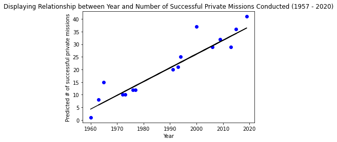

```python
years_new = np.array(years)
counts_new = np.array(counts)

X = years_new.reshape(-1,1)
y = counts_new.reshape(-1,1)

SEED = 42

X_train, X_test, y_train, y_test = train_test_split(X, y, test_size = 0.25, random_state = SEED)

regr = LinearRegression()
regr.fit(X_train, y_train)

print('Score: ', regr.score(X_test, y_test))
print('y-intercept: ', regr.intercept_.squeeze())
print('slope: ', regr.coef_.squeeze())
print()

# testing how strong the model is
y_pred = regr.predict(X_test)
# using X_test data to compare predicted y outputs with actual y outputs
df_preds = pd.DataFrame({'Actual': y_test.squeeze(), 'Predicted': y_pred.squeeze()})
print(df_preds)

# using metrics to evaluate the model
mae = mean_absolute_error(y_test, y_pred)
mse = mean_squared_error(y_test, y_pred)
rmse = np.sqrt(mse)
print('Mean absolute error: ', mae)
print('Mean squared error: ', mse)
print('Root mean squared error: ', rmse)
print()
# plot for visualizing regression line
plt.scatter(X_test, y_test, color ='b')
plt.plot(X_test, y_pred, color ='k')
plt.xlabel('Year')
plt.ylabel('Predicted # of successful private missions')
plt.title('Displaying Relationship between Year and Number of Successful Private Missions Conducted (1957 - 2020)')
plt.show()
```

## Relationship between private or state run missions and the activity status of the rockets used in their launches

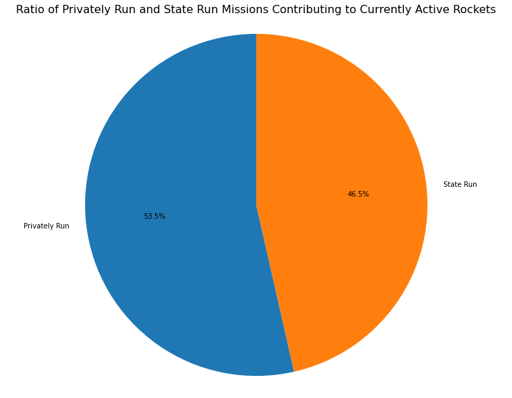

```python
launches_new = launches[launches['Status Rocket'] == 'StatusActive']

p_count = 0
s_count = 0




for index, row in launches_new.iterrows():
    if row['Private or State Run'] == 'P':
        p_count += 1
    else:
        s_count += 1

p_active_ratio = p_count / (s_count + p_count)
s_active_ratio = s_count / (s_count + p_count)

labels = ['Privately Run', 'State Run']
ratios = [p_active_ratio, s_active_ratio]

f, ax = plt.subplots(figsize=(13,10))
ax.pie(ratios, labels=labels, autopct='%1.1f%%', startangle=90)
ax.axis('equal')  # Equal aspect ratio ensures that pie is drawn as a circle.
plt.title('Ratio of Privately Run and State Run Missions Contributing to Currently Active Rockets', size=16)
plt.show()
```

Tying it back with the variable that sparked this series of analysis, Status Rocket, we see that out of all the missions for which the rocket used is still actove, 53.5% percent of the launches were privately-run, and 46.5% of the missions were state-run. Although the difference in percentages isn't very drastic, this can be considered as a measure of success for the privately-run missions. Yay for the private industry!